# Lab 5: Factors in Visualizations

- Show All Code
- Hide All Code
- View Source

Author

Leticia Mezzetti

# **Lab 5: Factors in Visualizations**

#### Set Up

```r
library(tidyverse)
library(here)
library(forcats)
library(dplyr)
```

```r
surveys <- read_csv(here("Labs", "surveys.csv"))
```

## **1. Revisiting Lab 2**

#### Boxplot for Relationship between Weight and Rodent Species

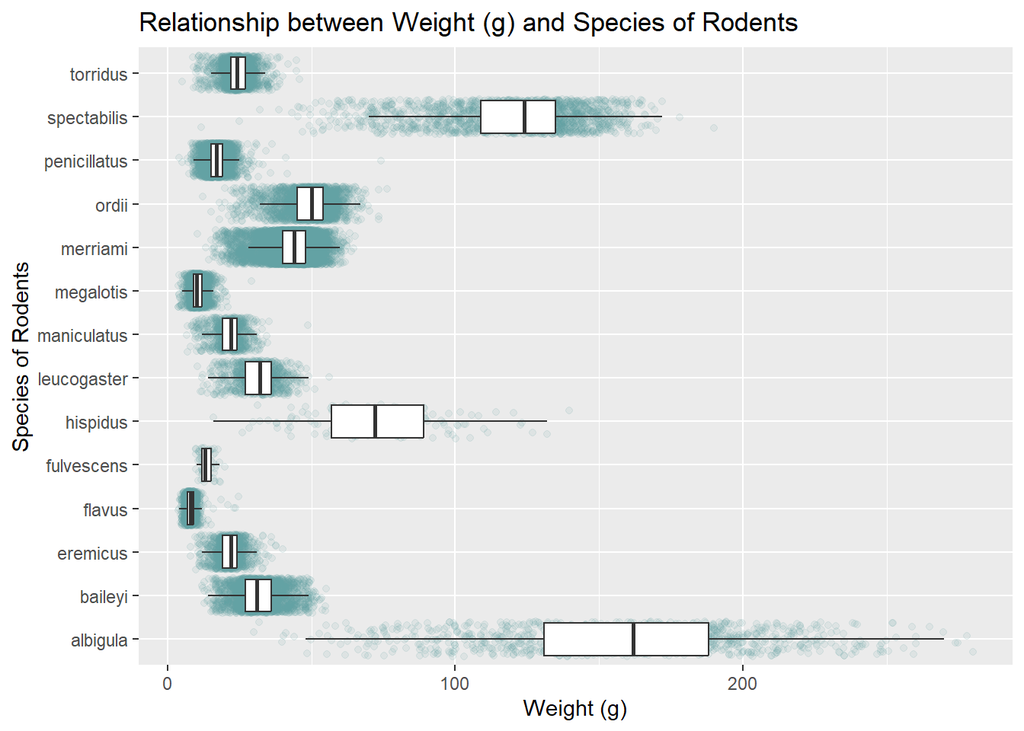

```r
ggplot(data = surveys,
        mapping = aes(x = weight,
                      y = species)) +
          geom_jitter(alpha = 0.1,
                      color = "cadetblue") +
            geom_boxplot(outlier.shape = NA) +
  labs(x = "Weight (g)",
       y = "Species of Rodents",
       title = "Relationship between Weight (g) and Species of Rodents")
```

**1. Reorder the species so the boxplots for weights go in descending order (largest to smallest).**

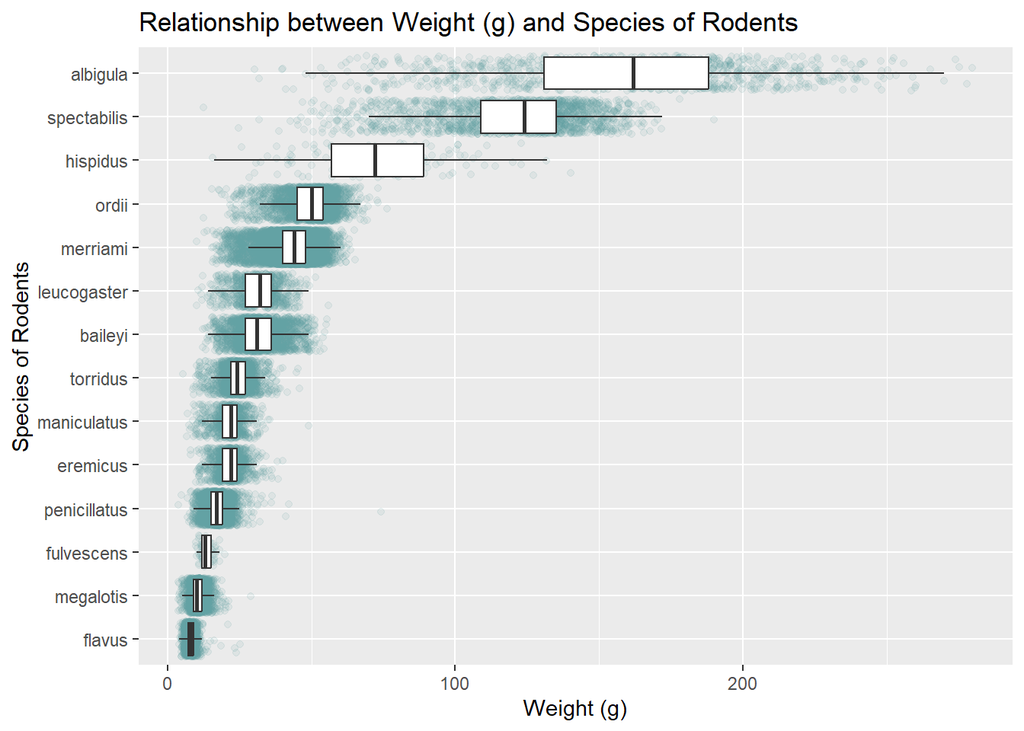

```r
  ggplot(data = surveys,
        mapping = aes(x = weight,
                      y = fct_reorder(species, weight))) +
          geom_jitter(alpha = 0.1,
                      color = "cadetblue") +
            geom_boxplot(outlier.shape = NA) +
  labs(x = "Weight (g)",
       y = "Species of Rodents",
       title = "Relationship between Weight (g) and Species of Rodents")
```

**2. Now that you’ve reordered, look at your y-axis label. That’s long! Let’s take Will Chase’s advice and move the y-axis label to the top of the plot.**

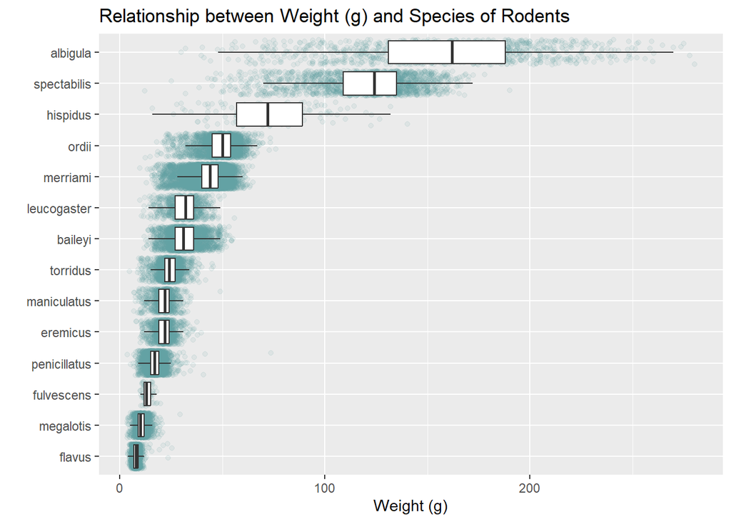

```r
  ggplot(data = surveys,
        mapping = aes(x = weight,
                      y = fct_reorder(species, weight))) +
          geom_jitter(alpha = 0.1,
                      color = "cadetblue") +
            geom_boxplot(outlier.shape = NA) +
  labs(x = "Weight (g)",
       y = "",
       title = "Relationship between Weight (g) and Species of Rodents")
```

2. **Time-Series Plot**

**1. Create a visualization how weights vary for each genus over the duration of the study.**

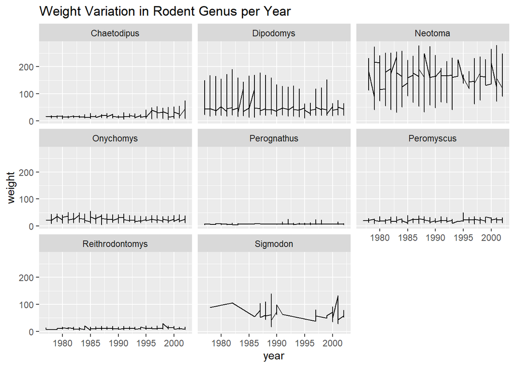

```r
year_summary <- surveys |>
  summarize(year, weight, genus)

ggplot(data = year_summary,
        mapping = aes(x = year,
                      y = weight)) +
  geom_line() +
  facet_wrap(~ genus) +
  labs(title = "Weight Variation in Rodent Genus per Year")
```

**2. Calculate and plot the mean weight for each genus for each year.**

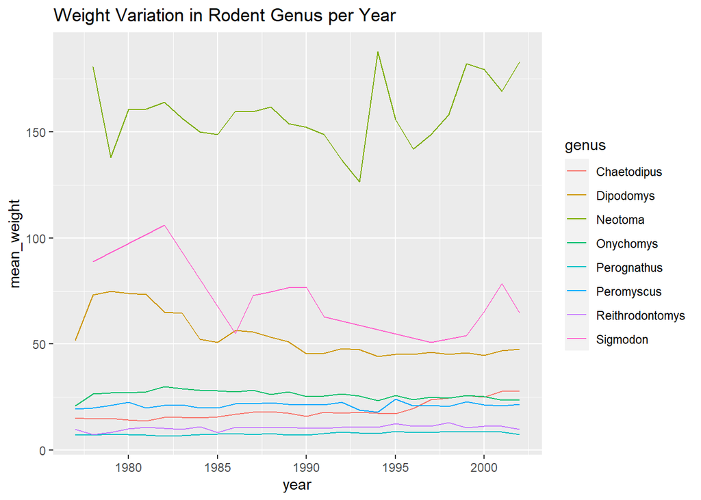

```r
year_summary <- surveys |>
  group_by(year, genus) |>
  summarize(mean_weight = mean(weight, na.rm = TRUE))

ggplot(data = year_summary,
        mapping = aes(x = year,
                      y = mean_weight,
                      color = genus)) +
  geom_line() +
  labs(title = "Weight Variation in Rodent Genus per Year")
```

```r
# Learned more about summarize using https://www.neonscience.org/resources/learning-hub/tutorials/dc-time-series-subset-dplyr-r
```

**3. Reorder the lines so the mean weights go in descending order (largest to smallest).**

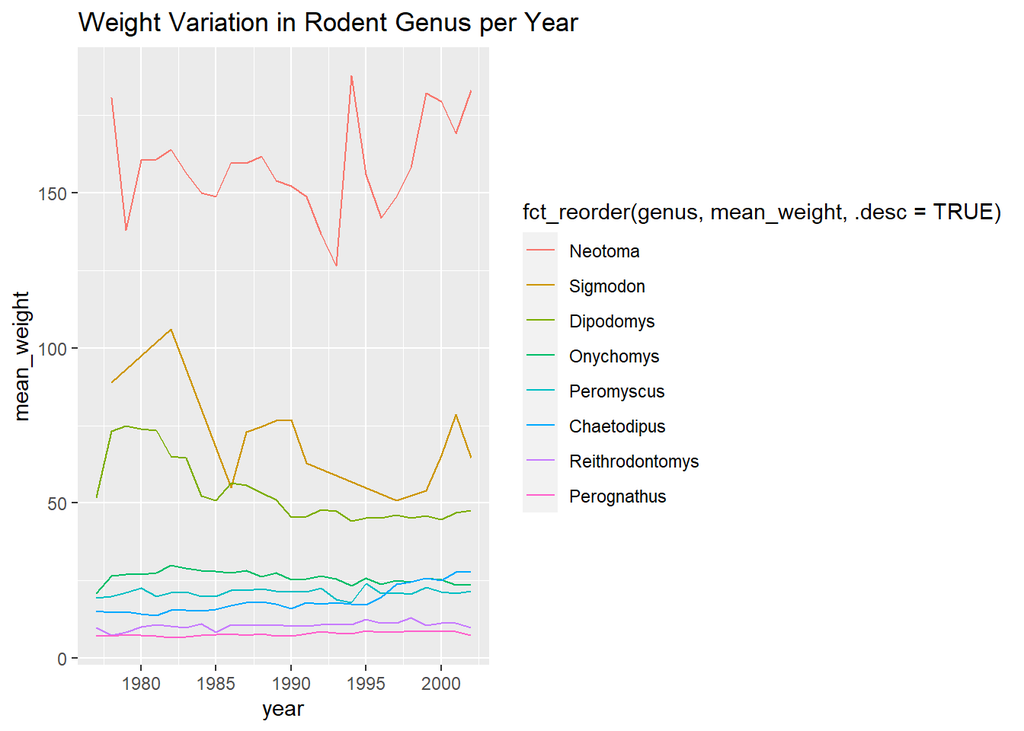

```r
year_summary <- surveys |>
  group_by(year, genus) |>
  summarize(mean_weight = mean(weight))

ggplot(data = year_summary,
        mapping = aes(x = year,
                      y = mean_weight,
                      color = fct_reorder(genus, mean_weight, .desc = TRUE))) +
  geom_line() +
  labs(title = "Weight Variation in Rodent Genus per Year")
```

**4. Now that you’ve reordered the lines, look at your legend’s label. That’s terrible! Let’s give the legend a new title *and* move the information from the y-axis to the plot title.**

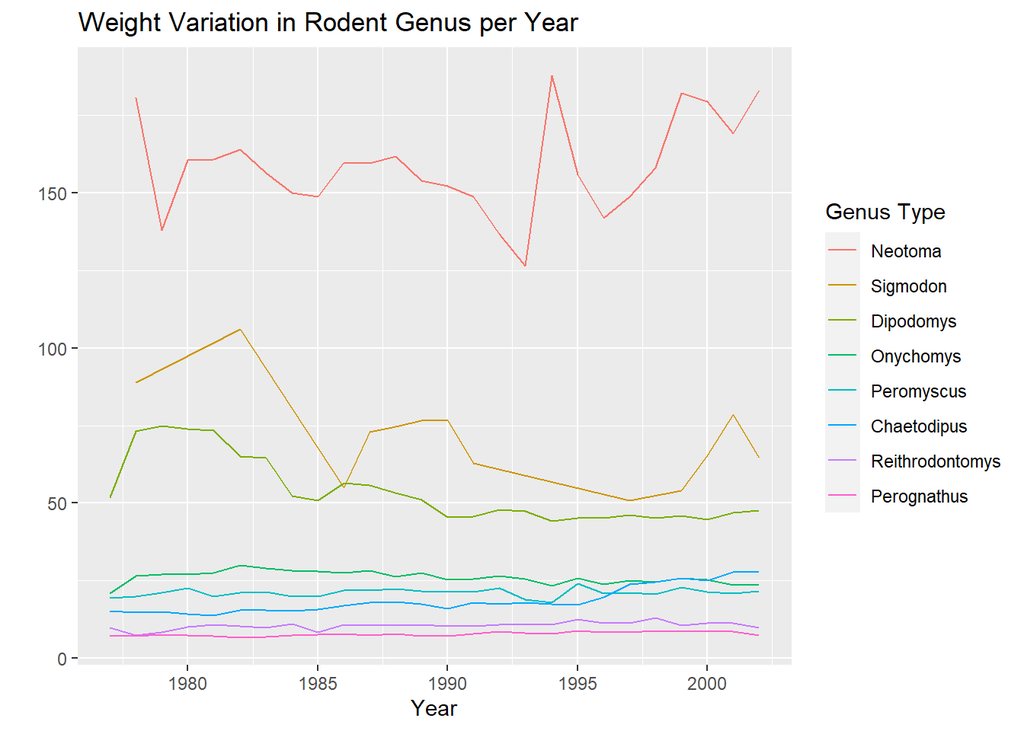

```r
year_summary <- surveys |>
  group_by(year, genus) |>
  summarize(mean_weight = mean(weight))

ggplot(data = year_summary,
        mapping = aes(x = year,
                      y = mean_weight,
                      color = fct_reorder(genus, mean_weight, .desc = TRUE))) +
  geom_line() +
  labs(title = "Weight Variation in Rodent Genus per Year",
       color = "Genus Type",
       x = "Year",
       y = "")
```

```r
# Resource used to changing legend title: https://stackoverflow.com/questions/52985946/change-legend-title-ggplot2
```

## **3. Caputures over the Week**

**1. Create a visualization of the number of rodents captured each day of the week.**

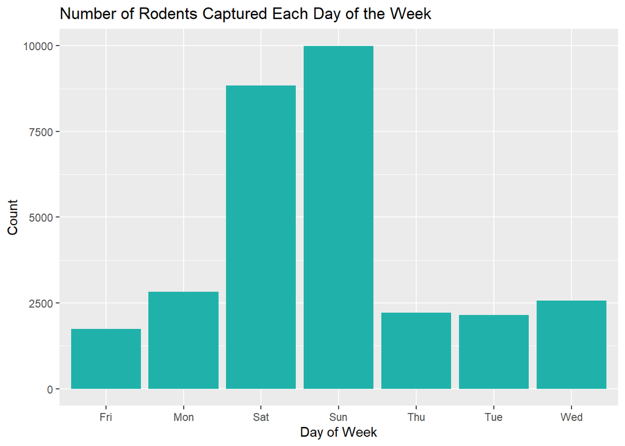

```r
surveys |>
  group_by(day_of_week) |>
  drop_na() |>
  ggplot(mapping <- aes(x = day_of_week)) +
  geom_bar(fill = "lightseagreen") +
  labs(title = "Number of Rodents Captured Each Day of the Week",
       x = "Day of Week",
       y = "Count")
```

**2. Change the order of the day of the week to go Monday through Sunday.**

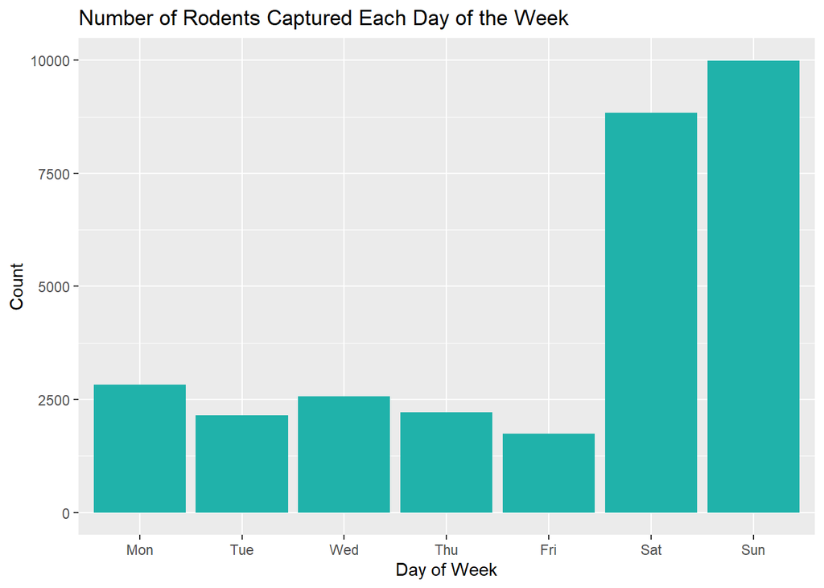

```r
day_order <- c("Mon", "Tue", "Wed", "Thu", "Fri", "Sat", "Sun")

surveys |>
  group_by(day_of_week) |>
  drop_na() |>
  ggplot(mapping <- aes(x = factor(day_of_week,
                                     day_order))) +
  geom_bar(fill = "lightseagreen") +
  labs(title = "Number of Rodents Captured Each Day of the Week",
       x = "Day of Week",
       y = "Count")
```

**3. Collapse Monday through Friday into a `"Weekday"` level, and collapse Saturday and Sunday into a `"Weekend"` level. Plot the number of rodents captured between the two groups.**

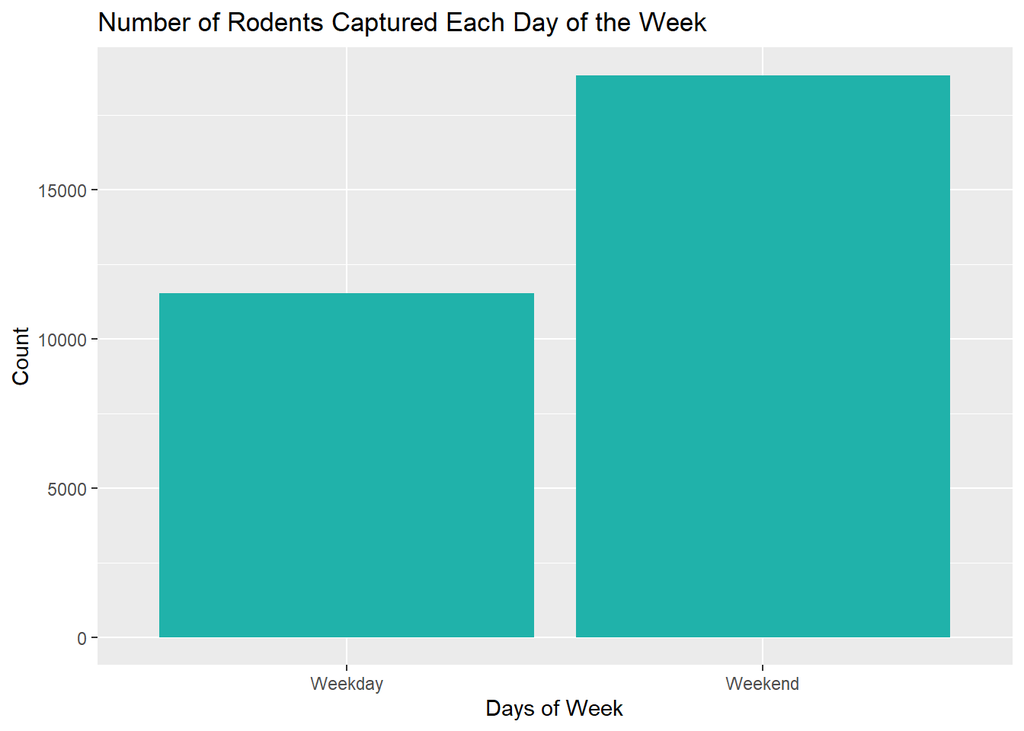

```r
weekday <- c("Mon", "Tue", "Wed", "Thu", "Fri")
weekend <- c("Sat", "Sun")

collapsed_days <- surveys |>
  mutate(day = fct_collapse(day_of_week,
                            "Weekday" = weekday,
                            "Weekend" = weekend)) |>
  drop_na()

ggplot(data = collapsed_days, mapping = aes(x = day)) +
  geom_bar(stat = "count", fill = "lightseagreen") +
  labs(title = "Number of Rodents Captured Each Day of the Week",
       x = "Days of Week",
       y = "Count")
```